# Blog3: PCA Linear Model

Jie Zou

2022-05-18

## My Thought

I was just gonna do some PCA in data transformation, but it turns out that I walk a little further, which I build a PCA linear model on the dataset from [Kaggle](https://www.kaggle.com/datasets/kuchhbhi/2022-march-laptop-data).

## Data Structure Overview

There is 896 observation and 22 features in the data. The Majority type of features are characters and integers. In addition, it does not seem to have missing values(i.e. NA)

```
## Rows: 896
## Columns: 22
## $ brand           <chr> "ASUS", "ASUS", "ASUS", "HP", "HP", "Lenovo", "HP", "A…
## $ model           <chr> "Celeron", "VivoBook", "Vivobook", "Core", "Core", "Id…
## $ processor_brand <chr> "Intel", "Intel", "Intel", "Intel", "Intel", "Intel", …
## $ processor_name  <chr> "Celeron Dual", "Core i3", "Core i3", "Core i3", "Core…
## $ processor_gnrtn <chr> "Missing", "10th", "10th", "11th", "11th", "10th", "Mi…
## $ ram_gb          <chr> "4", "8", "8", "8", "8", "8", "8", "4", "8", "8", "8",…
## $ ram_type        <chr> "DDR4", "DDR4", "DDR4", "DDR4", "DDR4", "DDR4", "DDR4"…
## $ ssd             <int> 0, 512, 0, 512, 512, 0, 256, 256, 256, 256, 512, 256, …
## $ hdd             <int> 1024, 0, 1024, 0, 0, 1024, 1024, 0, 1024, 0, 0, 0, 0, …
## $ os              <chr> "Windows", "Windows", "Windows", "Windows", "Windows",…
## $ os_bit          <int> 64, 64, 64, 64, 64, 64, 64, 64, 64, 32, 64, 64, 64, 64…
## $ graphic_card_gb <int> 0, 0, 0, 0, 0, 0, 0, 0, 0, 0, 0, 0, 4, 0, 0, 0, 0, 0, …
## $ weight          <chr> "Casual", "Casual", "Casual", "ThinNlight", "ThinNligh…
## $ display_size    <chr> "15.6", "15.6", "14.1", "15.6", "15.6", "15.6", "15.6"…
## $ warranty        <int> 1, 1, 1, 1, 0, 1, 1, 0, 1, 2, 1, 1, 1, 2, 1, 1, 0, 1, …
## $ Touchscreen     <chr> "No", "No", "No", "No", "No", "No", "No", "No", "No", …
## $ msoffice        <chr> "No", "No", "No", "Yes", "No", "Yes", "Yes", "No", "Ye…
## $ latest_price    <int> 23990, 37990, 32890, 42990, 54990, 35990, 41999, 34429…
## $ discount        <int> 11, 25, 30, 25, 21, 37, 13, 31, 24, 34, 23, 17, 17, 28…
## $ star_rating     <dbl> 3.8, 4.3, 3.9, 4.4, 4.2, 4.0, 4.3, 4.1, 5.0, 4.3, 4.1,…
## $ ratings         <int> 15279, 990, 28, 158, 116, 2124, 3524, 37, 7, 2080, 206…
## $ reviews         <int> 1947, 108, 4, 18, 15, 233, 432, 6, 5, 235, 17, 241, 53…
```

However, I find that there are data types of some features are not appropriate, therefore, the conversion between *integer* and *double* and the conversion between *integer* and *character* are necessary.

For Example:

- *ssd*: should be character because a laptop either has sdd or not, if it has it, the size of sdd is static.
- *hdd*: same as ssd
- *os_bit*: the size is fixed
- *graphic_card_gb*: same as ssd
- *discount*: percentage of discounts

## Data Structure After Fixing

```
## Rows: 896
## Columns: 22
## $ brand           <chr> "ASUS", "ASUS", "ASUS", "HP", "HP", "Lenovo", "HP", "A…
## $ model           <chr> "Celeron", "VivoBook", "Vivobook", "Core", "Core", "Id…
## $ processor_brand <chr> "Intel", "Intel", "Intel", "Intel", "Intel", "Intel", …
## $ processor_name  <chr> "Celeron Dual", "Core i3", "Core i3", "Core i3", "Core…
## $ processor_gnrtn <chr> "Missing", "10th", "10th", "11th", "11th", "10th", "Mi…
## $ ram_gb          <chr> "4", "8", "8", "8", "8", "8", "8", "4", "8", "8", "8",…
## $ ram_type        <chr> "DDR4", "DDR4", "DDR4", "DDR4", "DDR4", "DDR4", "DDR4"…
## $ ssd             <chr> "0", "512", "0", "512", "512", "0", "256", "256", "256…
## $ hdd             <chr> "1024", "0", "1024", "0", "0", "1024", "1024", "0", "1…
## $ os              <chr> "Windows", "Windows", "Windows", "Windows", "Windows",…
## $ os_bit          <chr> "64", "64", "64", "64", "64", "64", "64", "64", "64", …
## $ graphic_card_gb <chr> "0", "0", "0", "0", "0", "0", "0", "0", "0", "0", "0",…
## $ weight          <chr> "Casual", "Casual", "Casual", "ThinNlight", "ThinNligh…
## $ display_size    <chr> "15.6", "15.6", "14.1", "15.6", "15.6", "15.6", "15.6"…
## $ warranty        <int> 1, 1, 1, 1, 0, 1, 1, 0, 1, 2, 1, 1, 1, 2, 1, 1, 0, 1, …
## $ Touchscreen     <chr> "No", "No", "No", "No", "No", "No", "No", "No", "No", …
## $ msoffice        <chr> "No", "No", "No", "Yes", "No", "Yes", "Yes", "No", "Ye…
## $ latest_price    <int> 23990, 37990, 32890, 42990, 54990, 35990, 41999, 34429…
## $ discount        <dbl> 0.11, 0.25, 0.30, 0.25, 0.21, 0.37, 0.13, 0.31, 0.24, …
## $ star_rating     <dbl> 3.8, 4.3, 3.9, 4.4, 4.2, 4.0, 4.3, 4.1, 5.0, 4.3, 4.1,…
## $ ratings         <int> 15279, 990, 28, 158, 116, 2124, 3524, 37, 7, 2080, 206…
## $ reviews         <int> 1947, 108, 4, 18, 15, 233, 432, 6, 5, 235, 17, 241, 53…
```

## Examination of numerical variables

**Colinearity**

only rating and reviews are highly correlated, therefore, only one of two is kept.

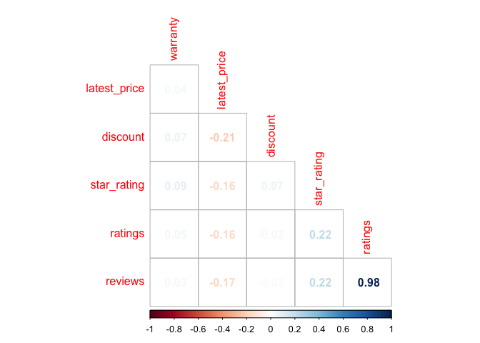

**Distributions**

The distribution of *ratings* and *reviews* have the same pattern which indicate that they are highly correlated as well.

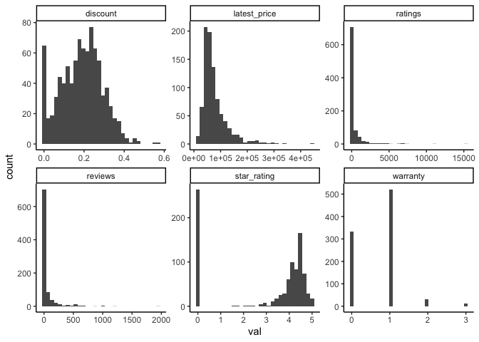

## Examination of Categorical Variables

**distribution of raw data**

The categorical variables looks pretty messy, even though I saw in the beginning that there is no NAs, there is plenty missing values in *processor generation* and *os* which state “Missing”. Meanwhile, by examining laptop model name, there are typos everywhere in the records, and in my opinion, a laptop model is based on its configuration, or it would probably just a name. As a result I am going to leave it out.

factor is better than character type in further analysis, so I am going to convert all character variable into factors

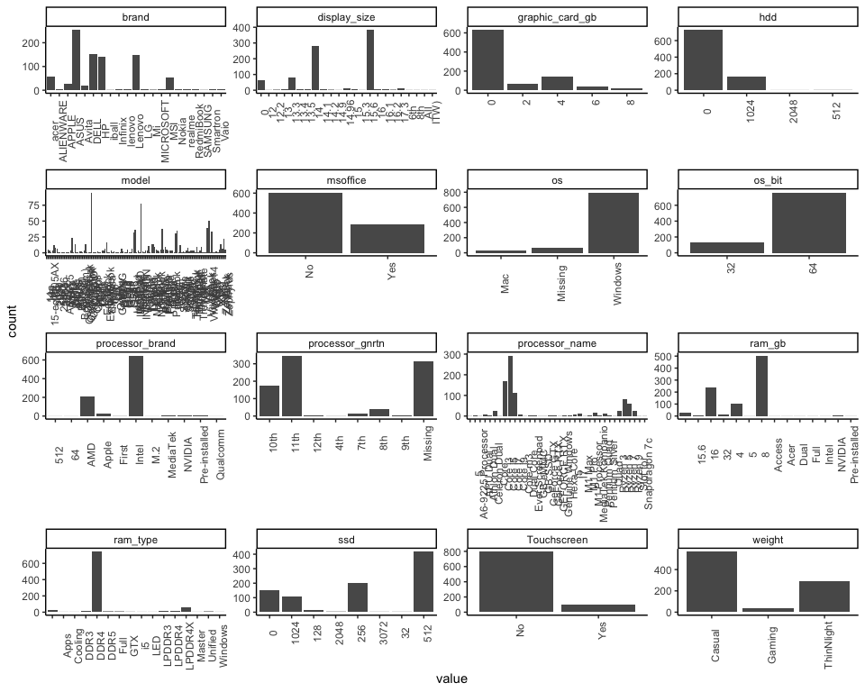

**distribution of tidy data**

Now it looks much better.

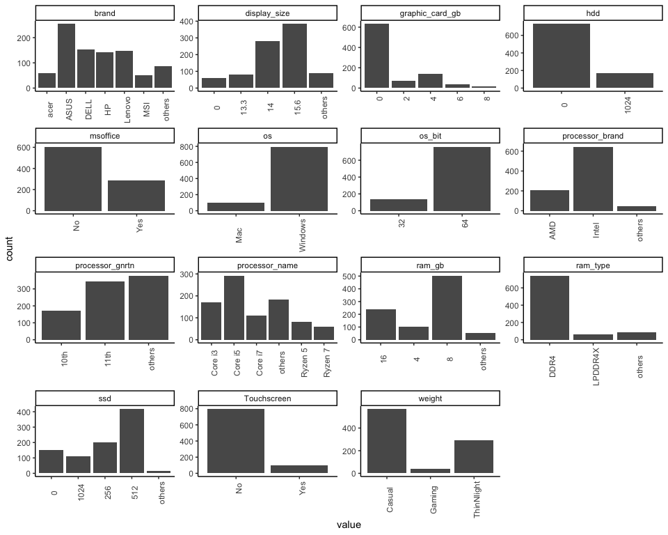

## Data Spliting

```
## [1] "dimension of training set: (672,44)"
```

```
## [1] "dimension of testing set: (224,44)"
```

## Modeling

**pca model in training set**

```
## Linear Regression
##
## 672 samples
##  43 predictor
##
## Pre-processing: centered (43), scaled (43), principal component
##  signal extraction (43)
## Resampling: Bootstrapped (25 reps)
## Summary of sample sizes: 672, 672, 672, 672, 672, 672, ...
## Resampling results:
##
##   RMSE      Rsquared  MAE
##   29302.26  0.658741  17974.88
##
## Tuning parameter 'intercept' was held constant at a value of TRUE
```

## Model Performance

**pca model evaluation performance in testing set**

```
## [1] "RMSE:24309.07"
```

```
## [1] "R-squared:0.630293"
```